# Assignment 4: IMDB Review Classification

**Method:** We compared a bidirectional LSTM using newly learned 100-dimensional word embeddings with the same LSTM using frozen pretrained GloVe 100-dimensional word embeddings. We used 150-token reviews, a vocabulary limit of 10,000 tokens, and 10,000 fixed validation examples. Each experiment adapted its vocabulary only on its own training reviews.

## Validation results

| Training reviews | Learned embedding | Pretrained GloVe | Winner |
| --- | --- | --- | --- |
| 100 | 52.4% | 51.2% | Learned embedding |
| 500 | 61.9% | 56.7% | Learned embedding |
| 2,000 | 79.3% | 67.3% | Learned embedding |
| 5,000 | 81.9% | 76.3% | Learned embedding |
| 10,000 | 83.4% | 79.5% | Learned embedding |

## Accuracy graph

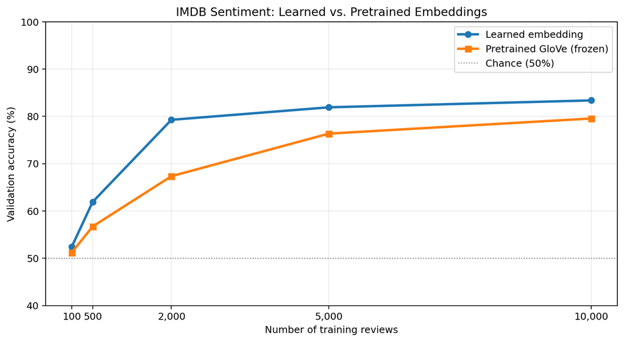

## Key findings

**At 100 reviews:** Learned embedding performed best.

First TESTED training size where learned embedding beat frozen GloVe: 100 reviews. This is not necessarily the exact crossover point between tested sizes.

## Explanation of the approaches

A learned embedding is a dictionary of word representations trained on the task. GloVe is a ready-made dictionary learned from a much larger text collection. With little training data, the pretrained dictionary can provide useful starting information, but the observed winner is determined by the table above.

An LSTM reads words step by step and keeps information about earlier words. A Transformer uses attention to connect important words across the text and adds position information to keep track of order. This experiment used an LSTM, not a Transformer.

**Limitations:** These are validation results from one configuration of a bidirectional LSTM. The findings may vary with training samples, model settings, and random seed. An untouched test set would provide additional evidence of generalization.